# Miniproject - Malaria

A T Chamberlain

2023-01-12 18:53

# Malaria Dataset

Data Challenge There is a Data Challenge hosted by the Wellcome Trust and Sage Bionetworks using the malariaAtlas package of data and tools. A lot of it is related to mapping, feel free to dive in and participate in their challenge or just stay within #TidyTuesday!

3 Datasets available:

- malaria_inc.csv - Malaria incidence by country for all ages across the world across time
- malaria_deaths.csv - Malaria deaths by country for all ages across the world and time.
- malaria_deaths_age.csv - Malaria deaths by age across the world and time.

## Data set dictionary of chosen dataset

### malaria_deaths.csv

Malaria deaths by country for all ages across the world and time.

- Entity : country name
- Code : 3 letter code
- Year : 1990 - 2016
- Deaths - Malaria - Sex: Both - Age: Age-standardized (Rate) (per 100,000 people)” range 0 to hundreds

## Plan of action

- Produce a static global map plot for 2016 using the malaria_deaths dataset
- Produce an animated global map of changes in Malaria deaths by country for each year 1990 to 2016

```
## [1] "Entity"
## [2] "Code"
## [3] "Year"
## [4] "Deaths - Malaria - Sex: Both - Age: Age-standardized (Rate) (per 100,000 people)"
```

```
## # A tibble: 6 × 4
##   Entity      Code   Year Deaths
##   <chr>       <chr> <dbl>  <dbl>
## 1 Afghanistan AFG    1990   6.80
## 2 Afghanistan AFG    1991   6.97
## 3 Afghanistan AFG    1992   6.99
## 4 Afghanistan AFG    1993   7.09
## 5 Afghanistan AFG    1994   7.39
## 6 Afghanistan AFG    1995   7.41
```

```
##    Min. 1st Qu.  Median    Mean 3rd Qu.    Max.
##    1990    1996    2003    2003    2010    2016
```

### Carry out some initial EDA

Note: EDA is for internal use/consumption so at this stage not pretty but do label to help my understanding. Density plots not that helpful as so skwed with most values at 0.0

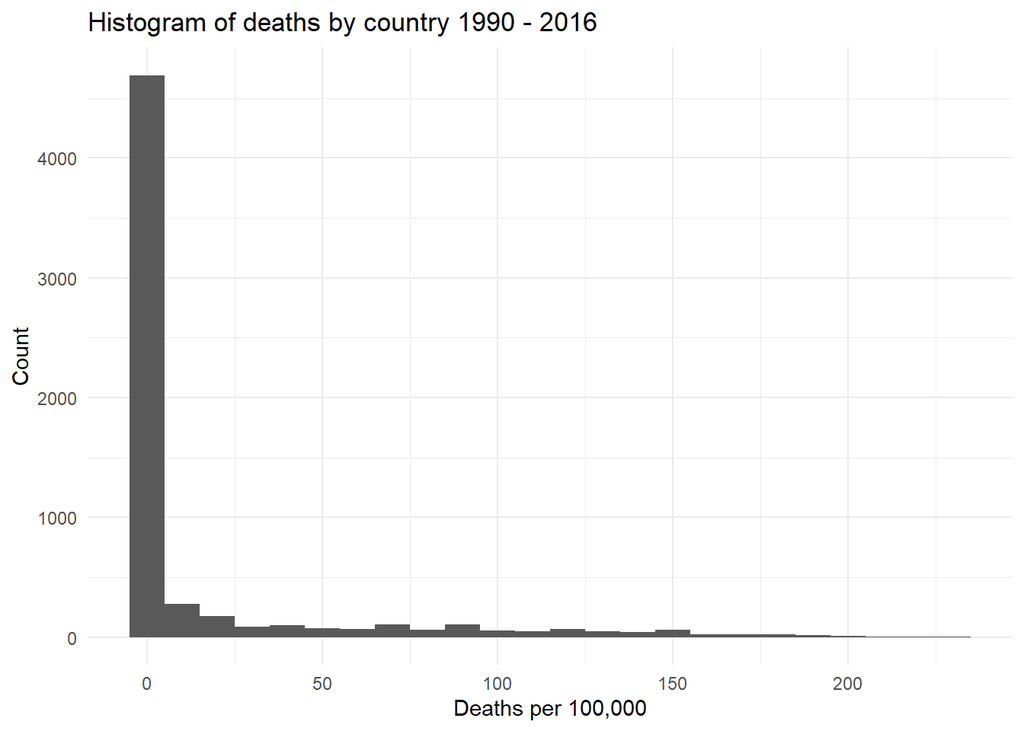

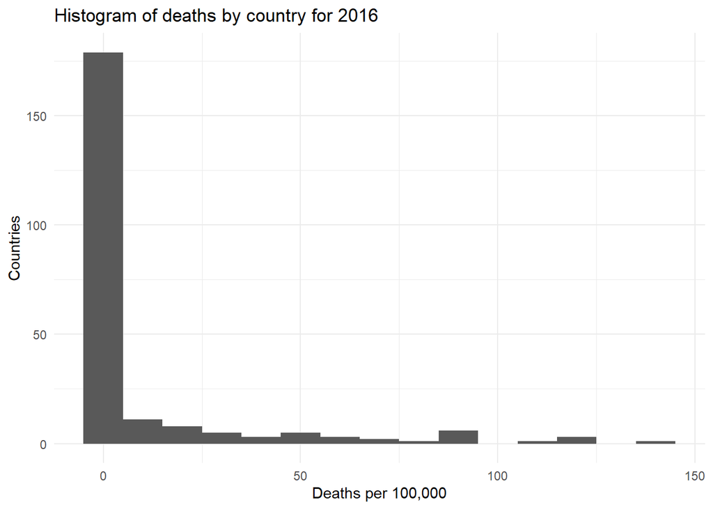

## Global maps

Set up and display a global map in iso projection

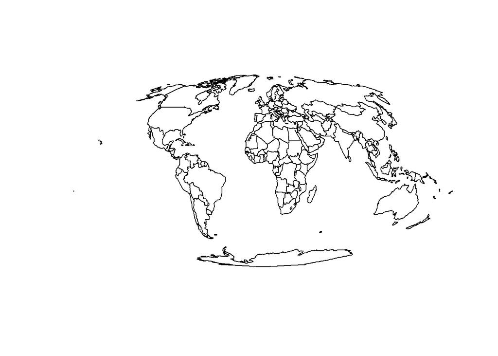

## Now merge the two datasets and display

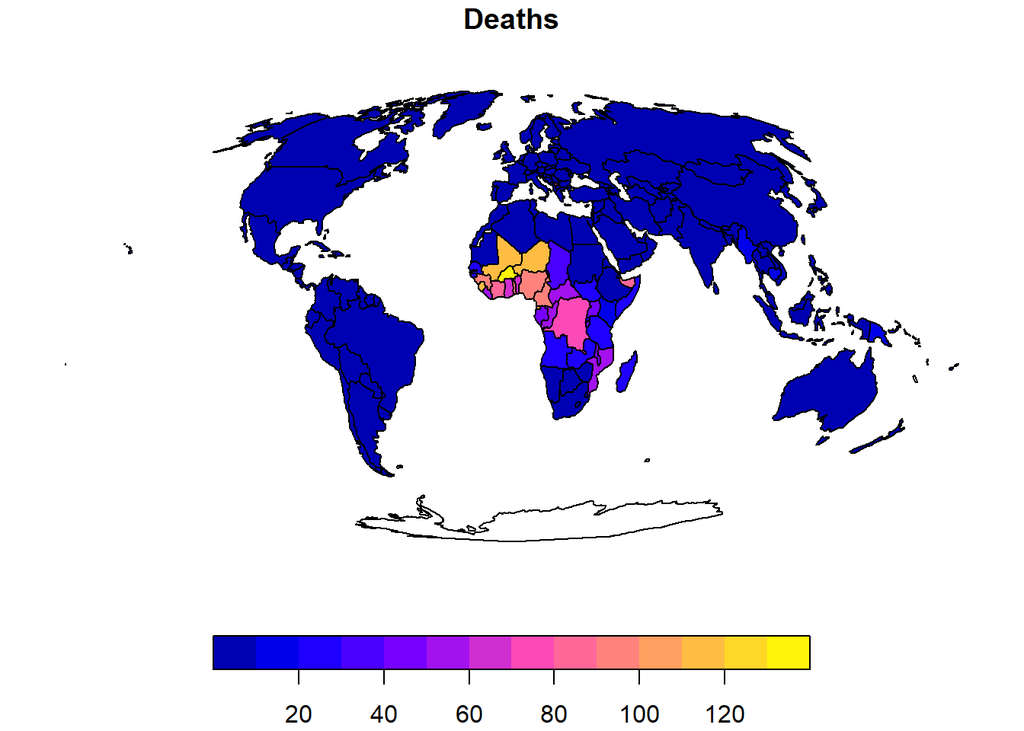

Current graph is basic but shows that malaria is mainly a problem in Africa and esp West Africa

Next step is the make it look better !

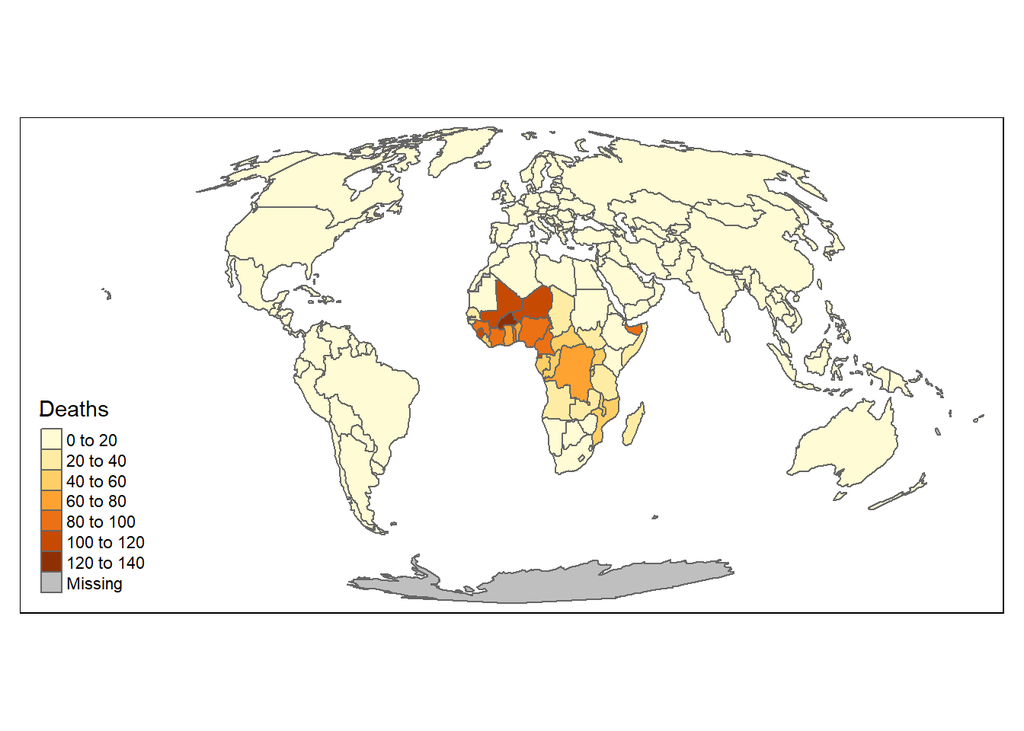

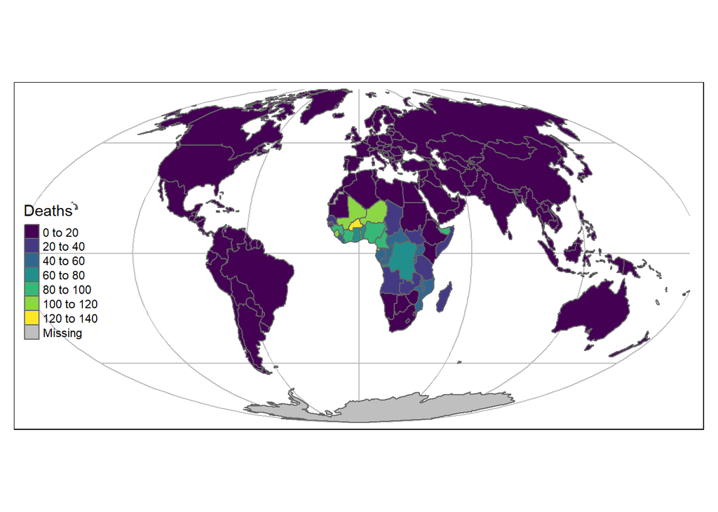

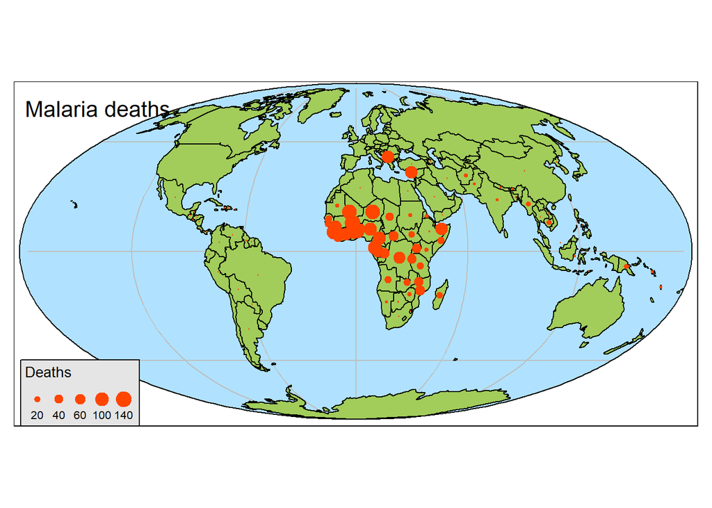

As noted in the lectures/labs colouring the countries means that data for v small counties is lost - eg ??Israel. Using colored dots is better as now shows up better.

That has acheived my first objective which was a static map and I have done some work to improve readability.

# Second objective

Aim is to map an interactive map for 1990 to 2016 to show how situation has changed over the years. Go back and complete the Lab exercise as first part of the cycle.

It seems that cannot get animated figures inserted in the html file by Knitr so will need to switch display mode

.